# Multiple Linear Regression

### Multiple Linear Regression

### Testing and training data

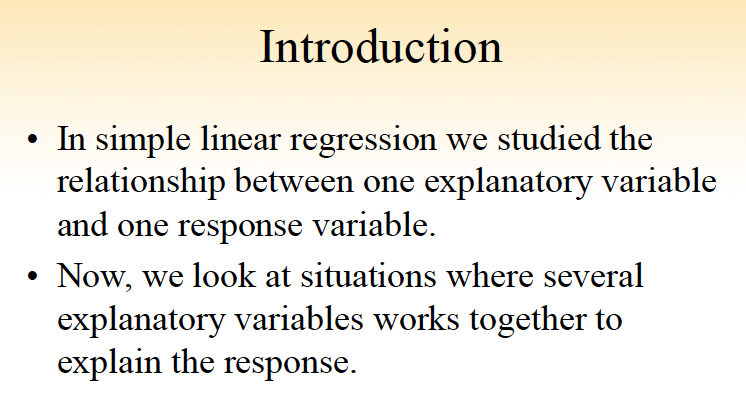

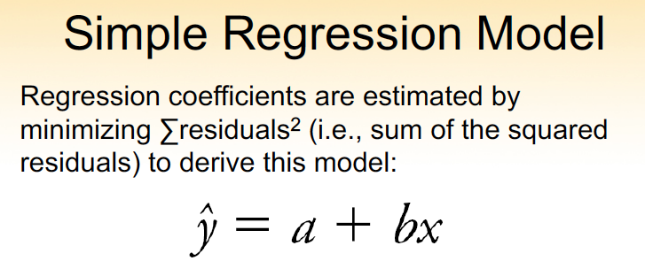

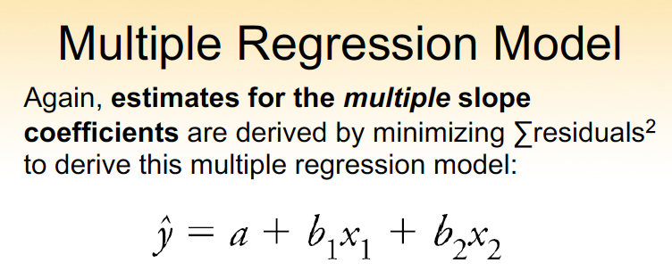

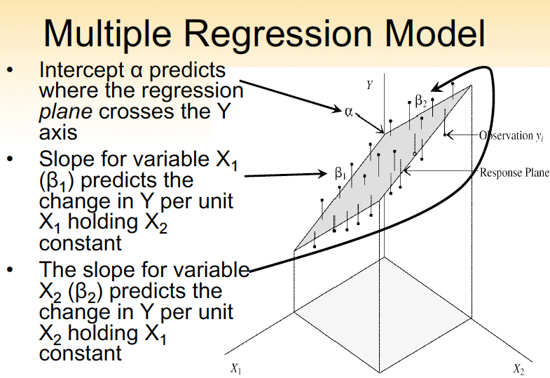

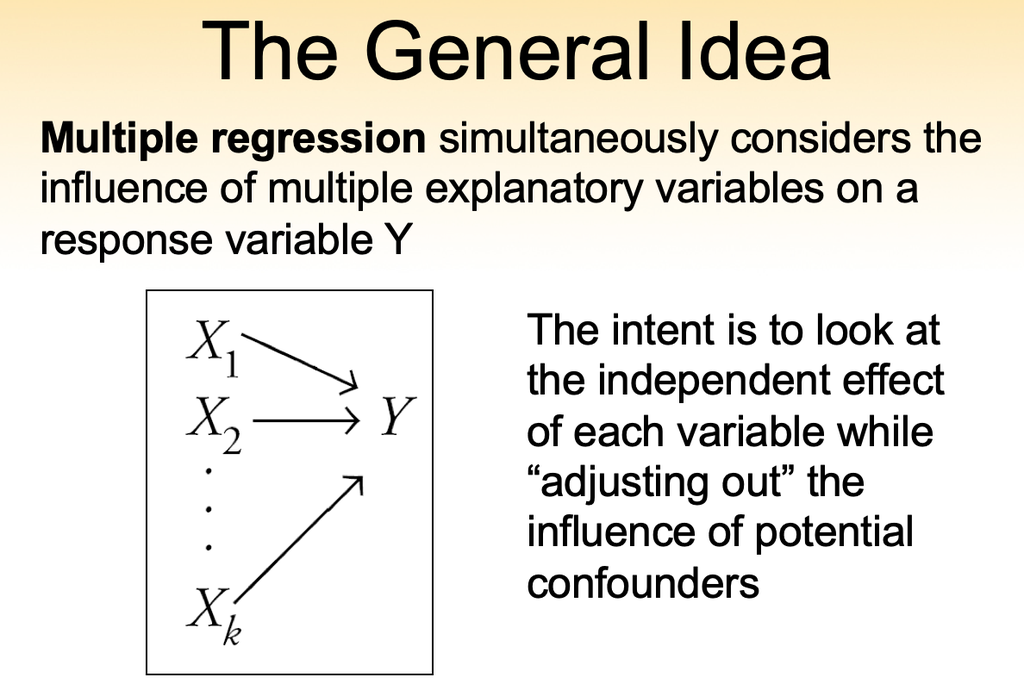

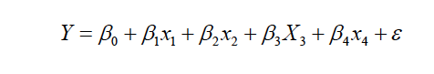

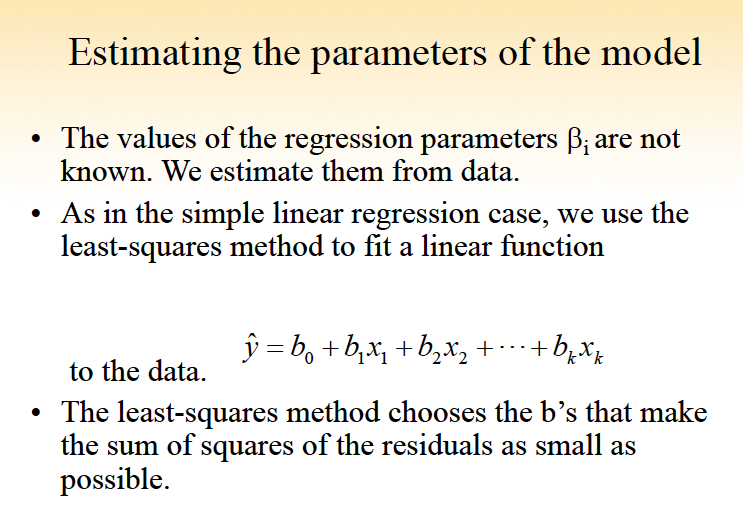

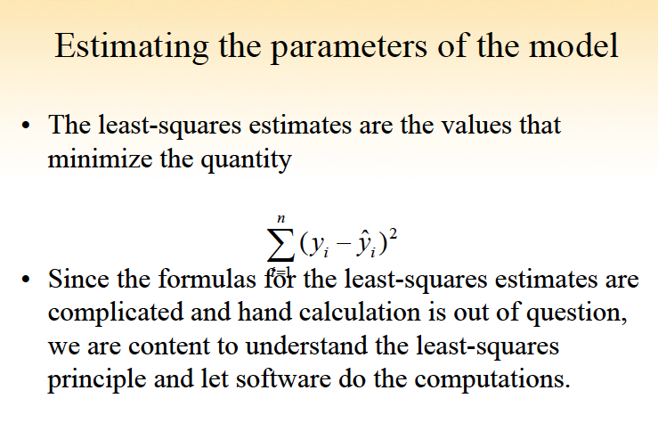

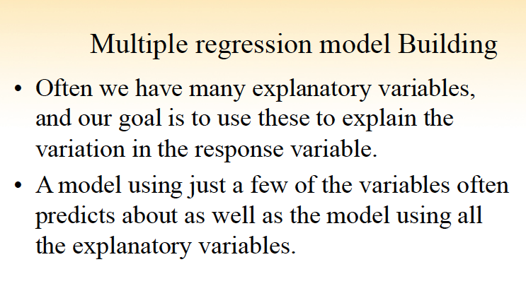

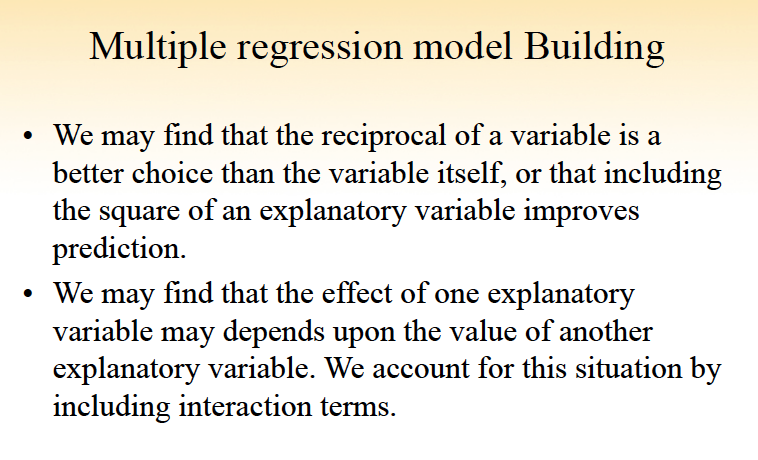

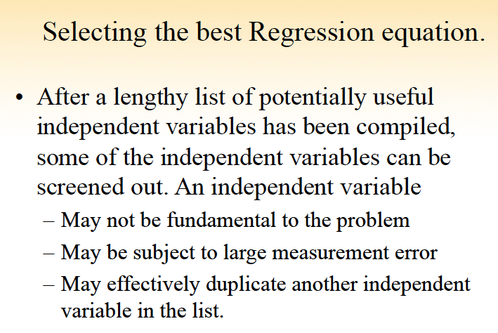

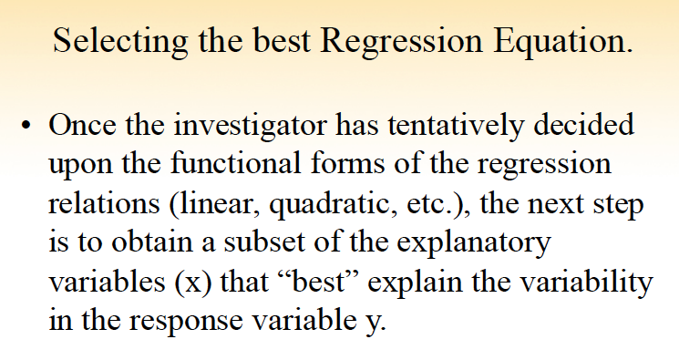

[7 more figures not shown]

The data set called Highway1 (used by by Carl Hoffstedt in his paper: https://rdrr.io/rforge/alr4/man/Highway1.html) relate the automobile accident rate, in accidents per million vehicle miles to several potential terms. The data include 39 sections of large Highways in the state of Minnesota in 1973. The goal of this analysis is to see how the rate variable are affetcted by some of the variables that are highly correlated with the rate and finding out which ones affect the rate variable the most.

This data frame contains the following columns:

adt - average daily traffic count in thousands

trks - truck volume as a percent of the total volume

lane - total number of lanes of traffic

acpt - number of access points per mile

sigs - number of signalized interchanges per mile

itg - number of freeway-type interchanges per mile

slim - speed limit in 1973

len - length of the Highway segment in miles

lwid - lane width, in feet

shld - width in feet of outer shoulder on the roadway

htype - An indicator of the type of roadway or the source of funding for the road; "mc" for major collector, "fai" for Federal interstate highways, "pa" for principal arterial highway, and "ma" for major arterial highways

rate - 1973 accident rate per million vehicle miles

```python
import pandas as pd
import numpy as np
import matplotlib as mpt
import matplotlib.pyplot as plt
import seaborn as sns
import statsmodels.api as sm
```

```python
hdata=pd.read_csv('Highway1.csv')
hdata.columns
```

```
Index(['Unnamed: 0', 'rate', 'len', 'ADT', 'trks', 'sigs1', 'slim', 'shld',
       'lane', 'acpt', 'itg', 'lwid', 'hwy'],
      dtype='object')
```

```python
hdata.head()
```

|  | Unnamed: 0 | rate | len | ADT | trks | sigs1 | slim | shld | lane | acpt | itg | lwid | hwy |
| --- | --- | --- | --- | --- | --- | --- | --- | --- | --- | --- | --- | --- | --- |
| 0 | 1 | 4.58 | 4.99 | 69 | 8 | 0.200401 | 55 | 10 | 8 | 4.6 | 1.20 | 12 | FAI |
| 1 | 2 | 2.86 | 16.11 | 73 | 8 | 0.062073 | 60 | 10 | 4 | 4.4 | 1.43 | 12 | FAI |
| 2 | 3 | 3.02 | 9.75 | 49 | 10 | 0.102564 | 60 | 10 | 4 | 4.7 | 1.54 | 12 | FAI |
| 3 | 4 | 2.29 | 10.65 | 61 | 13 | 0.093897 | 65 | 10 | 6 | 3.8 | 0.94 | 12 | FAI |
| 4 | 5 | 1.61 | 20.01 | 28 | 12 | 0.049975 | 70 | 10 | 4 | 2.2 | 0.65 | 12 | FAI |

```python
list(hdata.columns)
```

```
['Unnamed: 0',
 'rate',
 'len',
 'ADT',
 'trks',
 'sigs1',
 'slim',
 'shld',
 'lane',
 'acpt',
 'itg',
 'lwid',
 'hwy']
```

```python
cols=list(hdata.columns)
x= hdata[cols[2:12]]
x.head()
```

|  | len | ADT | trks | sigs1 | slim | shld | lane | acpt | itg | lwid |
| --- | --- | --- | --- | --- | --- | --- | --- | --- | --- | --- |
| 0 | 4.99 | 69 | 8 | 0.200401 | 55 | 10 | 8 | 4.6 | 1.20 | 12 |
| 1 | 16.11 | 73 | 8 | 0.062073 | 60 | 10 | 4 | 4.4 | 1.43 | 12 |
| 2 | 9.75 | 49 | 10 | 0.102564 | 60 | 10 | 4 | 4.7 | 1.54 | 12 |
| 3 | 10.65 | 61 | 13 | 0.093897 | 65 | 10 | 6 | 3.8 | 0.94 | 12 |
| 4 | 20.01 | 28 | 12 | 0.049975 | 70 | 10 | 4 | 2.2 | 0.65 | 12 |

```python
X=sm.add_constant(x)
y=hdata.rate
X.head()
```

|  | const | len | ADT | trks | sigs1 | slim | shld | lane | acpt | itg | lwid |
| --- | --- | --- | --- | --- | --- | --- | --- | --- | --- | --- | --- |
| 0 | 1.0 | 4.99 | 69 | 8 | 0.200401 | 55 | 10 | 8 | 4.6 | 1.20 | 12 |
| 1 | 1.0 | 16.11 | 73 | 8 | 0.062073 | 60 | 10 | 4 | 4.4 | 1.43 | 12 |
| 2 | 1.0 | 9.75 | 49 | 10 | 0.102564 | 60 | 10 | 4 | 4.7 | 1.54 | 12 |
| 3 | 1.0 | 10.65 | 61 | 13 | 0.093897 | 65 | 10 | 6 | 3.8 | 0.94 | 12 |
| 4 | 1.0 | 20.01 | 28 | 12 | 0.049975 | 70 | 10 | 4 | 2.2 | 0.65 | 12 |

```python
model0=sm.OLS(y,X).fit()
model0.summary()
```

OLS Regression Results

| Dep. Variable: | rate | R-squared: | 0.743 |
| --- | --- | --- | --- |
| Model: | OLS | Adj. R-squared: | 0.651 |
| Method: | Least Squares | F-statistic: | 8.080 |
| Date: | Mon, 12 Oct 2020 | Prob (F-statistic): | 5.72e-06 |
| Time: | 23:59:57 | Log-Likelihood: | -55.125 |
| No. Observations: | 39 | AIC: | 132.2 |
| Df Residuals: | 28 | BIC: | 150.5 |
| Df Model: | 10 |  |  |
| Covariance Type: | nonrobust |  |  |

|  | coef | std err | t | P>\|t\| | [0.025 | 0.975] |
| --- | --- | --- | --- | --- | --- | --- |
| const | 12.8175 | 5.969 | 2.147 | 0.041 | 0.591 | 25.044 |
| len | -0.0607 | 0.033 | -1.842 | 0.076 | -0.128 | 0.007 |
| ADT | 0.0037 | 0.032 | 0.114 | 0.910 | -0.062 | 0.069 |
| trks | -0.1148 | 0.103 | -1.119 | 0.272 | -0.325 | 0.095 |
| sigs1 | 0.4053 | 0.404 | 1.002 | 0.325 | -0.423 | 1.233 |
| slim | -0.0593 | 0.063 | -0.947 | 0.352 | -0.188 | 0.069 |
| shld | -0.0908 | 0.108 | -0.844 | 0.406 | -0.311 | 0.130 |
| lane | 0.0197 | 0.274 | 0.072 | 0.943 | -0.542 | 0.582 |
| acpt | 0.0885 | 0.031 | 2.858 | 0.008 | 0.025 | 0.152 |
| itg | 0.2059 | 1.135 | 0.181 | 0.857 | -2.119 | 2.531 |
| lwid | -0.3867 | 0.475 | -0.815 | 0.422 | -1.359 | 0.585 |

| Omnibus: | 0.400 | Durbin-Watson: | 2.537 |
| --- | --- | --- | --- |
| Prob(Omnibus): | 0.819 | Jarque-Bera (JB): | 0.239 |
| Skew: | 0.187 | Prob(JB): | 0.887 |
| Kurtosis: | 2.913 | Cond. No. | 2.03e+03 |

Warnings:  
[1] Standard Errors assume that the covariance matrix of the errors is correctly specified.  
[2] The condition number is large, 2.03e+03. This might indicate that there are  
strong multicollinearity or other numerical problems.

```python
x.columns
```

```
Index(['len', 'ADT', 'trks', 'sigs1', 'slim', 'shld', 'lane', 'acpt', 'itg',
       'lwid'],
      dtype='object')
```

```python
cols1=['len', 'ADT', 'trks', 'sigs1', 'slim', 'shld', 'acpt', 'itg','lwid']
x1= hdata[cols1]
x1.head(3)
```

|  | len | ADT | trks | sigs1 | slim | shld | acpt | itg | lwid |
| --- | --- | --- | --- | --- | --- | --- | --- | --- | --- |
| 0 | 4.99 | 69 | 8 | 0.200401 | 55 | 10 | 4.6 | 1.20 | 12 |
| 1 | 16.11 | 73 | 8 | 0.062073 | 60 | 10 | 4.4 | 1.43 | 12 |
| 2 | 9.75 | 49 | 10 | 0.102564 | 60 | 10 | 4.7 | 1.54 | 12 |

```python
X1=sm.add_constant(x1)
model1=sm.OLS(y,X1).fit()
model1.summary()
```

OLS Regression Results

| Dep. Variable: | rate | R-squared: | 0.743 |
| --- | --- | --- | --- |
| Model: | OLS | Adj. R-squared: | 0.663 |
| Method: | Least Squares | F-statistic: | 9.296 |
| Date: | Tue, 13 Oct 2020 | Prob (F-statistic): | 1.79e-06 |
| Time: | 00:15:26 | Log-Likelihood: | -55.128 |
| No. Observations: | 39 | AIC: | 130.3 |
| Df Residuals: | 29 | BIC: | 146.9 |
| Df Model: | 9 |  |  |
| Covariance Type: | nonrobust |  |  |

|  | coef | std err | t | P>\|t\| | [0.025 | 0.975] |
| --- | --- | --- | --- | --- | --- | --- |
| const | 12.8342 | 5.861 | 2.190 | 0.037 | 0.847 | 24.822 |
| len | -0.0603 | 0.032 | -1.884 | 0.070 | -0.126 | 0.005 |
| ADT | 0.0049 | 0.026 | 0.187 | 0.853 | -0.049 | 0.059 |
| trks | -0.1156 | 0.100 | -1.153 | 0.258 | -0.321 | 0.089 |
| sigs1 | 0.4142 | 0.378 | 1.096 | 0.282 | -0.359 | 1.187 |
| slim | -0.0590 | 0.061 | -0.961 | 0.344 | -0.185 | 0.067 |
| shld | -0.0899 | 0.105 | -0.856 | 0.399 | -0.305 | 0.125 |
| acpt | 0.0883 | 0.030 | 2.914 | 0.007 | 0.026 | 0.150 |
| itg | 0.1955 | 1.106 | 0.177 | 0.861 | -2.067 | 2.458 |
| lwid | -0.3866 | 0.466 | -0.829 | 0.414 | -1.340 | 0.567 |

| Omnibus: | 0.374 | Durbin-Watson: | 2.544 |
| --- | --- | --- | --- |
| Prob(Omnibus): | 0.830 | Jarque-Bera (JB): | 0.244 |
| Skew: | 0.186 | Prob(JB): | 0.885 |
| Kurtosis: | 2.890 | Cond. No. | 2.03e+03 |

Warnings:  
[1] Standard Errors assume that the covariance matrix of the errors is correctly specified.  
[2] The condition number is large, 2.03e+03. This might indicate that there are  
strong multicollinearity or other numerical problems.

```python
x2= x1[['len', 'ADT', 'trks', 'sigs1', 'slim', 'shld', 'acpt','lwid']]
X2=sm.add_constant(x2)
model2=sm.OLS(y,X2).fit()
model2.summary()
```

OLS Regression Results

| Dep. Variable: | rate | R-squared: | 0.742 |
| --- | --- | --- | --- |
| Model: | OLS | Adj. R-squared: | 0.674 |
| Method: | Least Squares | F-statistic: | 10.80 |
| Date: | Tue, 13 Oct 2020 | Prob (F-statistic): | 5.23e-07 |
| Time: | 00:20:17 | Log-Likelihood: | -55.149 |
| No. Observations: | 39 | AIC: | 128.3 |
| Df Residuals: | 30 | BIC: | 143.3 |
| Df Model: | 8 |  |  |
| Covariance Type: | nonrobust |  |  |

|  | coef | std err | t | P>\|t\| | [0.025 | 0.975] |
| --- | --- | --- | --- | --- | --- | --- |
| const | 12.8462 | 5.765 | 2.228 | 0.034 | 1.072 | 24.621 |
| len | -0.0609 | 0.031 | -1.945 | 0.061 | -0.125 | 0.003 |
| ADT | 0.0091 | 0.012 | 0.751 | 0.458 | -0.016 | 0.034 |
| trks | -0.1159 | 0.099 | -1.176 | 0.249 | -0.317 | 0.085 |
| sigs1 | 0.4040 | 0.368 | 1.099 | 0.280 | -0.347 | 1.155 |
| slim | -0.0571 | 0.059 | -0.961 | 0.344 | -0.179 | 0.064 |
| shld | -0.0938 | 0.101 | -0.929 | 0.360 | -0.300 | 0.112 |
| acpt | 0.0889 | 0.030 | 3.003 | 0.005 | 0.028 | 0.149 |
| lwid | -0.3955 | 0.456 | -0.867 | 0.393 | -1.327 | 0.536 |

| Omnibus: | 0.446 | Durbin-Watson: | 2.555 |
| --- | --- | --- | --- |
| Prob(Omnibus): | 0.800 | Jarque-Bera (JB): | 0.272 |
| Skew: | 0.200 | Prob(JB): | 0.873 |
| Kurtosis: | 2.915 | Cond. No. | 2.03e+03 |

Warnings:  
[1] Standard Errors assume that the covariance matrix of the errors is correctly specified.  
[2] The condition number is large, 2.03e+03. This might indicate that there are  
strong multicollinearity or other numerical problems.

```python
x3= x2[['len', 'trks', 'sigs1', 'slim', 'shld', 'acpt','lwid']]
X3=sm.add_constant(x3)
model3=sm.OLS(y,X3).fit()
model3.summary()
```

OLS Regression Results

| Dep. Variable: | rate | R-squared: | 0.737 |
| --- | --- | --- | --- |
| Model: | OLS | Adj. R-squared: | 0.678 |
| Method: | Least Squares | F-statistic: | 12.44 |
| Date: | Tue, 13 Oct 2020 | Prob (F-statistic): | 1.82e-07 |
| Time: | 00:22:11 | Log-Likelihood: | -55.513 |
| No. Observations: | 39 | AIC: | 127.0 |
| Df Residuals: | 31 | BIC: | 140.3 |
| Df Model: | 7 |  |  |
| Covariance Type: | nonrobust |  |  |

|  | coef | std err | t | P>\|t\| | [0.025 | 0.975] |
| --- | --- | --- | --- | --- | --- | --- |
| const | 12.6986 | 5.721 | 2.219 | 0.034 | 1.030 | 24.367 |
| len | -0.0645 | 0.031 | -2.098 | 0.044 | -0.127 | -0.002 |
| trks | -0.1114 | 0.098 | -1.140 | 0.263 | -0.311 | 0.088 |
| sigs1 | 0.4680 | 0.355 | 1.319 | 0.197 | -0.256 | 1.192 |
| slim | -0.0615 | 0.059 | -1.046 | 0.304 | -0.181 | 0.058 |
| shld | -0.0680 | 0.094 | -0.721 | 0.476 | -0.260 | 0.124 |
| acpt | 0.0840 | 0.029 | 2.929 | 0.006 | 0.026 | 0.142 |
| lwid | -0.3603 | 0.450 | -0.800 | 0.430 | -1.279 | 0.558 |

| Omnibus: | 0.122 | Durbin-Watson: | 2.419 |
| --- | --- | --- | --- |
| Prob(Omnibus): | 0.941 | Jarque-Bera (JB): | 0.229 |
| Skew: | 0.120 | Prob(JB): | 0.892 |
| Kurtosis: | 2.711 | Cond. No. | 1.92e+03 |

Warnings:  
[1] Standard Errors assume that the covariance matrix of the errors is correctly specified.  
[2] The condition number is large, 1.92e+03. This might indicate that there are  
strong multicollinearity or other numerical problems.

```python
x4= x3[['len', 'trks', 'sigs1', 'slim', 'acpt','lwid']]
X4=sm.add_constant(x4)
model4=sm.OLS(y,X4).fit()
model4.summary()
```

OLS Regression Results

| Dep. Variable: | rate | R-squared: | 0.733 |
| --- | --- | --- | --- |
| Model: | OLS | Adj. R-squared: | 0.683 |
| Method: | Least Squares | F-statistic: | 14.65 |
| Date: | Tue, 13 Oct 2020 | Prob (F-statistic): | 5.70e-08 |
| Time: | 00:24:57 | Log-Likelihood: | -55.837 |
| No. Observations: | 39 | AIC: | 125.7 |
| Df Residuals: | 32 | BIC: | 137.3 |
| Df Model: | 6 |  |  |
| Covariance Type: | nonrobust |  |  |

|  | coef | std err | t | P>\|t\| | [0.025 | 0.975] |
| --- | --- | --- | --- | --- | --- | --- |
| const | 12.4384 | 5.667 | 2.195 | 0.036 | 0.895 | 23.982 |
| len | -0.0581 | 0.029 | -1.989 | 0.055 | -0.118 | 0.001 |
| trks | -0.1014 | 0.096 | -1.057 | 0.299 | -0.297 | 0.094 |
| sigs1 | 0.4357 | 0.349 | 1.247 | 0.222 | -0.276 | 1.148 |
| slim | -0.0901 | 0.043 | -2.095 | 0.044 | -0.178 | -0.003 |
| acpt | 0.0847 | 0.028 | 2.979 | 0.005 | 0.027 | 0.143 |
| lwid | -0.2600 | 0.425 | -0.611 | 0.545 | -1.126 | 0.606 |

| Omnibus: | 0.152 | Durbin-Watson: | 2.360 |
| --- | --- | --- | --- |
| Prob(Omnibus): | 0.927 | Jarque-Bera (JB): | 0.262 |
| Skew: | 0.134 | Prob(JB): | 0.877 |
| Kurtosis: | 2.701 | Cond. No. | 1.90e+03 |

Warnings:  
[1] Standard Errors assume that the covariance matrix of the errors is correctly specified.  
[2] The condition number is large, 1.9e+03. This might indicate that there are  
strong multicollinearity or other numerical problems.

```python
x5= x4[['len', 'trks', 'sigs1', 'slim', 'acpt']]
X5=sm.add_constant(x5)
model5=sm.OLS(y,X5).fit()
model5.summary()
```

OLS Regression Results

| Dep. Variable: | rate | R-squared: | 0.730 |
| --- | --- | --- | --- |
| Model: | OLS | Adj. R-squared: | 0.689 |
| Method: | Least Squares | F-statistic: | 17.84 |
| Date: | Tue, 13 Oct 2020 | Prob (F-statistic): | 1.51e-08 |
| Time: | 00:27:25 | Log-Likelihood: | -56.064 |
| No. Observations: | 39 | AIC: | 124.1 |
| Df Residuals: | 33 | BIC: | 134.1 |
| Df Model: | 5 |  |  |
| Covariance Type: | nonrobust |  |  |

|  | coef | std err | t | P>\|t\| | [0.025 | 0.975] |
| --- | --- | --- | --- | --- | --- | --- |
| const | 9.4004 | 2.700 | 3.482 | 0.001 | 3.907 | 14.894 |
| len | -0.0531 | 0.028 | -1.912 | 0.065 | -0.110 | 0.003 |
| trks | -0.0986 | 0.095 | -1.038 | 0.307 | -0.292 | 0.095 |
| sigs1 | 0.4378 | 0.346 | 1.265 | 0.215 | -0.266 | 1.142 |
| slim | -0.0931 | 0.042 | -2.201 | 0.035 | -0.179 | -0.007 |
| acpt | 0.0851 | 0.028 | 3.022 | 0.005 | 0.028 | 0.142 |

| Omnibus: | 0.378 | Durbin-Watson: | 2.337 |
| --- | --- | --- | --- |
| Prob(Omnibus): | 0.828 | Jarque-Bera (JB): | 0.510 |
| Skew: | 0.198 | Prob(JB): | 0.775 |
| Kurtosis: | 2.603 | Cond. No. | 895. |

Warnings:  
[1] Standard Errors assume that the covariance matrix of the errors is correctly specified.

```python
x6= x5[['len', 'sigs1', 'slim', 'acpt']]
X6=sm.add_constant(x6)
model6=sm.OLS(y,X6).fit()
model6.summary()
```

OLS Regression Results

| Dep. Variable: | rate | R-squared: | 0.721 |
| --- | --- | --- | --- |
| Model: | OLS | Adj. R-squared: | 0.688 |
| Method: | Least Squares | F-statistic: | 21.98 |
| Date: | Tue, 13 Oct 2020 | Prob (F-statistic): | 4.95e-09 |
| Time: | 00:29:20 | Log-Likelihood: | -56.691 |
| No. Observations: | 39 | AIC: | 123.4 |
| Df Residuals: | 34 | BIC: | 131.7 |
| Df Model: | 4 |  |  |
| Covariance Type: | nonrobust |  |  |

|  | coef | std err | t | P>\|t\| | [0.025 | 0.975] |
| --- | --- | --- | --- | --- | --- | --- |
| const | 8.6349 | 2.600 | 3.321 | 0.002 | 3.350 | 13.919 |
| len | -0.0641 | 0.026 | -2.492 | 0.018 | -0.116 | -0.012 |
| sigs1 | 0.5280 | 0.335 | 1.574 | 0.125 | -0.154 | 1.210 |
| slim | -0.0948 | 0.042 | -2.240 | 0.032 | -0.181 | -0.009 |
| acpt | 0.0879 | 0.028 | 3.133 | 0.004 | 0.031 | 0.145 |

| Omnibus: | 0.854 | Durbin-Watson: | 2.336 |
| --- | --- | --- | --- |
| Prob(Omnibus): | 0.653 | Jarque-Bera (JB): | 0.904 |
| Skew: | 0.307 | Prob(JB): | 0.636 |
| Kurtosis: | 2.576 | Cond. No. | 850. |

Warnings:  
[1] Standard Errors assume that the covariance matrix of the errors is correctly specified.

```python
x7= x6[['len', 'slim', 'acpt']]
X7=sm.add_constant(x7)
model7=sm.OLS(y,X7).fit()
model7.summary()
```

OLS Regression Results

| Dep. Variable: | rate | R-squared: | 0.701 |
| --- | --- | --- | --- |
| Model: | OLS | Adj. R-squared: | 0.675 |
| Method: | Least Squares | F-statistic: | 27.33 |
| Date: | Tue, 13 Oct 2020 | Prob (F-statistic): | 2.76e-09 |
| Time: | 00:30:25 | Log-Likelihood: | -58.062 |
| No. Observations: | 39 | AIC: | 124.1 |
| Df Residuals: | 35 | BIC: | 130.8 |
| Df Model: | 3 |  |  |
| Covariance Type: | nonrobust |  |  |

|  | coef | std err | t | P>\|t\| | [0.025 | 0.975] |
| --- | --- | --- | --- | --- | --- | --- |
| const | 9.3256 | 2.617 | 3.564 | 0.001 | 4.014 | 14.638 |
| len | -0.0771 | 0.025 | -3.102 | 0.004 | -0.128 | -0.027 |
| slim | -0.1024 | 0.043 | -2.386 | 0.023 | -0.190 | -0.015 |
| acpt | 0.1014 | 0.027 | 3.721 | 0.001 | 0.046 | 0.157 |

| Omnibus: | 0.311 | Durbin-Watson: | 2.155 |
| --- | --- | --- | --- |
| Prob(Omnibus): | 0.856 | Jarque-Bera (JB): | 0.493 |
| Skew: | 0.097 | Prob(JB): | 0.782 |
| Kurtosis: | 2.485 | Cond. No. | 837. |

Warnings:  
[1] Standard Errors assume that the covariance matrix of the errors is correctly specified.

```python
hdata.shape
```

```
(39, 13)
```

## Final Model

Rate $= 9.3256\, -0.0771\,$ len $-0.1024\,$ slim $ + 0.1014 $ acpt

```python
hdata.corr()
```

|  | Unnamed: 0 | rate | len | ADT | trks | sigs1 | slim | shld | lane | acpt | itg | lwid |
| --- | --- | --- | --- | --- | --- | --- | --- | --- | --- | --- | --- | --- |
| Unnamed: 0 | 1.000000 | 0.032470 | 0.362779 | -0.846241 | 0.104887 | -0.286362 | -0.292009 | -0.591370 | -0.773467 | 0.281647 | -0.726426 | -0.227827 |
| rate | 0.032470 | 1.000000 | -0.465290 | -0.028570 | -0.512522 | 0.603191 | -0.680984 | -0.386907 | -0.032979 | 0.752025 | -0.024841 | -0.005619 |
| len | 0.362779 | -0.465290 | 1.000000 | -0.271569 | 0.495943 | -0.391851 | 0.186243 | -0.104926 | -0.202504 | -0.238706 | -0.247562 | -0.310650 |
| ADT | -0.846241 | -0.028570 | -0.271569 | 1.000000 | -0.096682 | 0.159381 | 0.244157 | 0.457307 | 0.823930 | -0.223980 | 0.903701 | 0.127878 |
| trks | 0.104887 | -0.512522 | 0.495943 | -0.096682 | 1.000000 | -0.475308 | 0.296184 | 0.006135 | -0.153324 | -0.360266 | -0.067231 | -0.155271 |
| sigs1 | -0.286362 | 0.603191 | -0.391851 | 0.159381 | -0.475308 | 1.000000 | -0.424415 | -0.124103 | 0.263967 | 0.513461 | 0.087017 | 0.062084 |
| slim | -0.292009 | -0.680984 | 0.186243 | 0.244157 | 0.296184 | -0.424415 | 1.000000 | 0.689009 | 0.264520 | -0.681521 | 0.241282 | 0.098693 |
| shld | -0.591370 | -0.386907 | -0.104926 | 0.457307 | 0.006135 | -0.124103 | 0.689009 | 1.000000 | 0.481771 | -0.424951 | 0.375022 | -0.042896 |
| lane | -0.773467 | -0.032979 | -0.202504 | 0.823930 | -0.153324 | 0.263967 | 0.264520 | 0.481771 | 1.000000 | -0.208779 | 0.697913 | 0.095723 |
| acpt | 0.281647 | 0.752025 | -0.238706 | -0.223980 | -0.360266 | 0.513461 | -0.681521 | -0.424951 | -0.208779 | 1.000000 | -0.200158 | -0.042013 |
| itg | -0.726426 | -0.024841 | -0.247562 | 0.903701 | -0.067231 | 0.087017 | 0.241282 | 0.375022 | 0.697913 | -0.200158 | 1.000000 | 0.102883 |
| lwid | -0.227827 | -0.005619 | -0.310650 | 0.127878 | -0.155271 | 0.062084 | 0.098693 | -0.042896 | 0.095723 | -0.042013 | 0.102883 | 1.000000 |

```python
xx= hdata[['len', 'slim', 'acpt']]
y= hdata.rate
```

```python
from sklearn.model_selection import train_test_split
```

```python
xtrain, xtest, ytrain, ytest = train_test_split(xx, y, test_size=0.2)
```

```python
xtrain.shape
```

```
(31, 3)
```

```python
xtest.shape
```

```
(8, 3)
```

```python
ytrain.shape
```

```
(31,)
```

```python
ytest.shape
```

```
(8,)
```

```python
modelxx=sm.OLS(ytrain,sm.add_constant(xtrain)).fit()
modelxx.summary()
```

OLS Regression Results

| Dep. Variable: | rate | R-squared: | 0.619 |
| --- | --- | --- | --- |
| Model: | OLS | Adj. R-squared: | 0.577 |
| Method: | Least Squares | F-statistic: | 14.63 |
| Date: | Tue, 13 Oct 2020 | Prob (F-statistic): | 7.51e-06 |
| Time: | 00:47:59 | Log-Likelihood: | -46.418 |
| No. Observations: | 31 | AIC: | 100.8 |
| Df Residuals: | 27 | BIC: | 106.6 |
| Df Model: | 3 |  |  |
| Covariance Type: | nonrobust |  |  |

|  | coef | std err | t | P>\|t\| | [0.025 | 0.975] |
| --- | --- | --- | --- | --- | --- | --- |
| const | 9.6263 | 2.925 | 3.291 | 0.003 | 3.624 | 15.628 |
| len | -0.0767 | 0.027 | -2.826 | 0.009 | -0.132 | -0.021 |
| slim | -0.1120 | 0.047 | -2.379 | 0.025 | -0.209 | -0.015 |
| acpt | 0.1317 | 0.042 | 3.149 | 0.004 | 0.046 | 0.218 |

| Omnibus: | 2.262 | Durbin-Watson: | 1.616 |
| --- | --- | --- | --- |
| Prob(Omnibus): | 0.323 | Jarque-Bera (JB): | 1.417 |
| Skew: | -0.250 | Prob(JB): | 0.492 |
| Kurtosis: | 2.080 | Cond. No. | 822. |

Warnings:  
[1] Standard Errors assume that the covariance matrix of the errors is correctly specified.

```python
ypred =modelxx.predict(sm.add_constant(xtest))
```

```python
xx.head()
```

|  | len | slim | acpt |
| --- | --- | --- | --- |
| 0 | 4.99 | 55 | 4.6 |
| 1 | 16.11 | 60 | 4.4 |
| 2 | 9.75 | 60 | 4.7 |
| 3 | 10.65 | 65 | 3.8 |
| 4 | 20.01 | 70 | 2.2 |

```python
y.head()
```

```
0    4.58
1    2.86
2    3.02
3    2.29
4    1.61
Name: rate, dtype: float64
```

```python
ypred
```

```
28     7.676821
23     2.111936
6      4.255810
17     4.775735
35     5.094971
19     2.373323
24    11.850557
7      5.499098
dtype: float64
```

```python
ytest
```

```
28    7.48
23    1.81
6     3.85
17    4.22
35    2.76
19    2.55
24    9.23
7     6.12
Name: rate, dtype: float64
```

```python
from sklearn.metrics import r2_score
r2_score(ytest, ypred)
```

```
0.7217139335667455
```

Adjusted $R^2= 1-(1- R^2)\dfrac{n-1}{n-p-1}$

```python
adjrsquared = 1-(1-0.7217139335667455)* (31-1)/(31-3-1)
adjrsquared
```

```
0.6907932595186062
```